# PCA First

## C. 2 RCP Scenarios

What happens when we include a second scenario??

So lets combine temp for RCP 85 and 26

**Expectations:** That there more PCs will contribute to the variance and that the PCs will retain similar shapes may be?

```r
# Start by importing, checking and formatting the emissions driven run results.
paths <- list.files(file.path(BASE, 'data-raw', 'PCA_hector_ensemble'), 'emission_rcp85|emission_rcp26',
                    full.names = TRUE)
wide_data <- foreach(input = paths, .combine = 'full_join') %do% {

    # Import the data
    str <- readRDS(input)

    # Format the scenario name a bit
    scn_name <- gsub(x = gsub(x = basename(input), pattern = '.rds', replacement = ''), pattern = '_', replacement = '~')

    # Foramt into as a wide tibble where one row represents on "case" of Hector.
    tibble::as_tibble(str$rslt) %>%
        filter(variable == 1) %>%
        mutate(index = paste0(scn_name, '_', variable, '_', year)) %>%
        select(run_id, index, value) %>%
        spread(index, value)

}
# Remove the run_id column so that the tibble only contains data that will be used in the PCA
temp_rcp85_rcp26 <- na.omit(select(wide_data, -run_id))
# Run the PCA on the data frame that contains the 2 scenarios
pca_temp_rcp85_rcp26 <- prcomp(x = temp_rcp85_rcp26, center = TRUE, scale = FALSE)
```

The fraction of the variance.

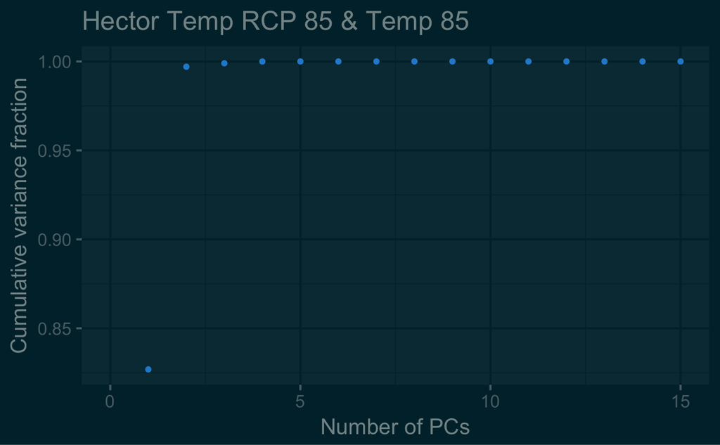

```r
frac_C <- calc_variance(pca_temp_rcp85_rcp26)
plot_frac(frac_C, title = 'Hector Temp RCP 85 & Temp 85') +
    coord_cartesian(xlim = c(0, 15)) +
    labs(substitle = 'I only ploted the first 15 PCs')
```

Interesting I would have expected that more PCs contribute to the variance. How does it compare to the other fraction of variance?

```r
# The fraction of the variance for the temp rcp 85 & rcp 85 pca
tibble::tibble( PC = 1:10,
                `temp 85 & 26` = frac_C[1:10],
                `temp 85 only` = fvar_temp_rcp85_B[1:10]) %>%
    knitr::kable()
```

| PC | temp 85 & 26 | temp 85 only |
| --- | --- | --- |
| 1 | 0.8268875 | 0.8374609 |
| 2 | 0.9970276 | 0.9990237 |
| 3 | 0.9989666 | 0.9999440 |
| 4 | 0.9999690 | 0.9999843 |
| 5 | 0.9999892 | 0.9999963 |
| 6 | 0.9999962 | 0.9999986 |
| 7 | 0.9999981 | 0.9999992 |
| 8 | 0.9999990 | 0.9999996 |
| 9 | 0.9999994 | 0.9999997 |
| 10 | 0.9999997 | 0.9999998 |

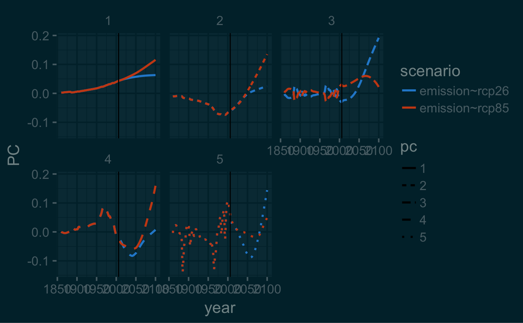

```r
unscaled_pca_rcp85_rcp26 <- plot_pcs(pca_temp_rcp85_rcp26, pc_indx = 1:5)
unscaled_pca_rcp85_rcp26 +
    geom_vline(aes(xintercept = 2006)) +
    facet_wrap('pc')
```

### What happens when we use prcomp to scale the PCA?

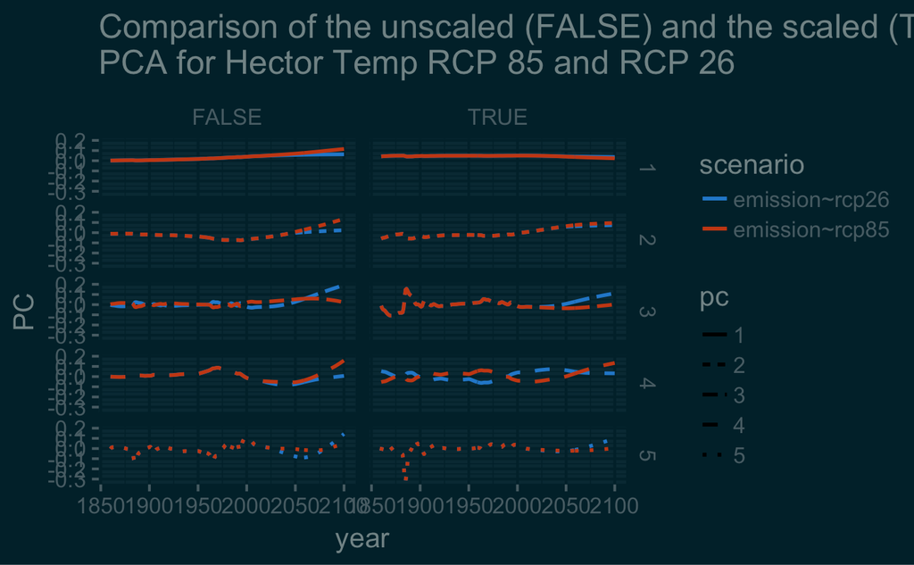

```r
pca_temp_rcp85_rcp26_scaled <- prcomp(x = temp_rcp85_rcp26, center = TRUE, scale = TRUE)
plot_pcs(pca_temp_rcp85_rcp26_scaled, pc_indx = 1:5) +
    geom_vline(aes(xintercept = 2006)) +
    facet_wrap('pc') ->
    sclaed_pca
unscaled_pca_rcp85_rcp26$data %>%
    mutate(scaled = FALSE) ->
    unscaled_data
unscaled_pca_rcp85_rcp26 %+% unscaled_data +
    geom_line(data = sclaed_pca$data %>%
                  mutate(scaled = TRUE),
              aes(year, value,  color = scenario, linetype = pc),
              size = 1) +
    facet_grid(`pc` ~ `scaled`) +
    labs(title = 'Comparison of the unscaled (FALSE) and the scaled (TRUE)\nPCA for Hector Temp RCP 85 and RCP 26')
```

**Conclusions:** As we expected when we increase the numer of scenarios going into the PCA less variance is explained by the first 3 PCs. The sahpes are somewhat similar to one another and diverge when the rcp emissions take over. Using the prncomp scale argument changed the shape a bit, I wasn’t expecting that… Where you?

## D. RCP 85 only but now let’s do CO2 and Tgav

**Expectation:** More PCs are going to contribute to the variance, I think that the PC for the CO2 and Tgav might be smiliar but on different scales.

```r
# Start by importing, checking and formatting the emissions driven run results.
paths <- list.files(file.path(BASE, 'data-raw', 'PCA_hector_ensemble'), 'emission_rcp85', full.names = TRUE)
wide_data <- foreach(input = paths, .combine = 'full_join') %do% {

    # Import the data
    str <- readRDS(input)

    # Format the scenario name a bit
    scn_name <- gsub(x = gsub(x = basename(input), pattern = '.rds', replacement = ''), pattern = '_', replacement = '~')

    # Foramt into as a wide tibble where one row represents on "case" of Hector.
    tibble::as_tibble(str$rslt) %>%
        mutate(index = paste0(scn_name, '_', variable, '_', year)) %>%
        na.omit %>%
        select(run_id, index, value) %>%
        spread(index, value)

}
# Remove the run_id column so that the tibble only contains data that will be used in the PCA
temp_co2_rcp85 <- na.omit(select(wide_data, -run_id))
# Run the PCA on the data frame that contains the 2 scenarios
pca_temp_co2_rcp85 <- prcomp(x = temp_co2_rcp85, center = TRUE, scale = FALSE)
```

```r
frac_temp_co2_rcp85 <- calc_variance(pca_temp_co2_rcp85)
frac_temp_co2_rcp85[1:10]
```

```
 [1] 0.9489775 0.9995715 0.9999233 0.9999678 0.9999850 0.9999925 0.9999955 0.9999972 0.9999981
[10] 0.9999989
```

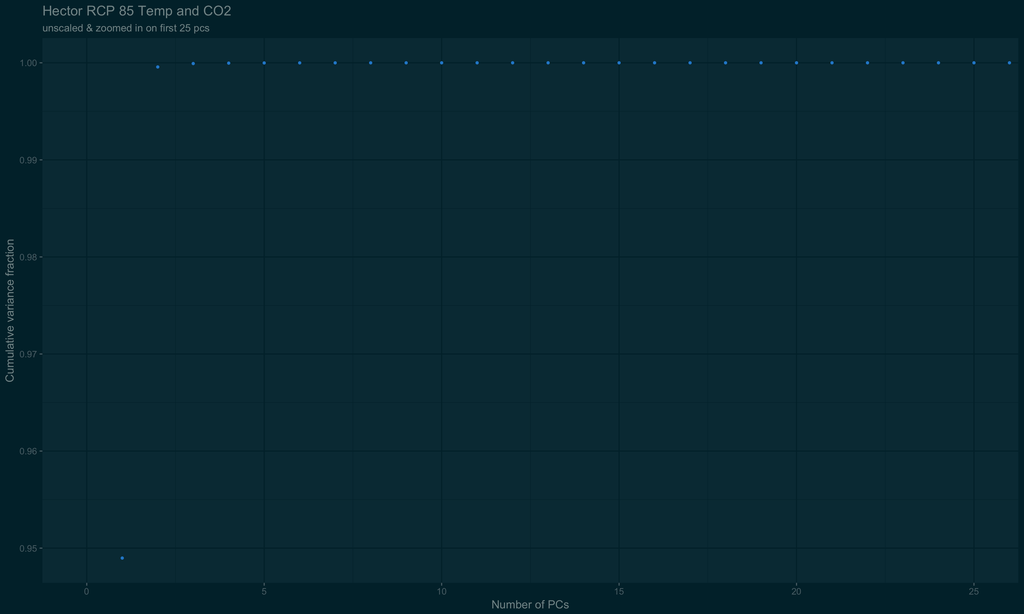

```r
plot_frac(frac_temp_co2_rcp85) +
    coord_cartesian(xlim = c(0, 25)) +
    labs(title = 'Hector RCP 85 Temp and CO2',
         subtitle = 'unscaled & zoomed in on first 25 pcs')
```

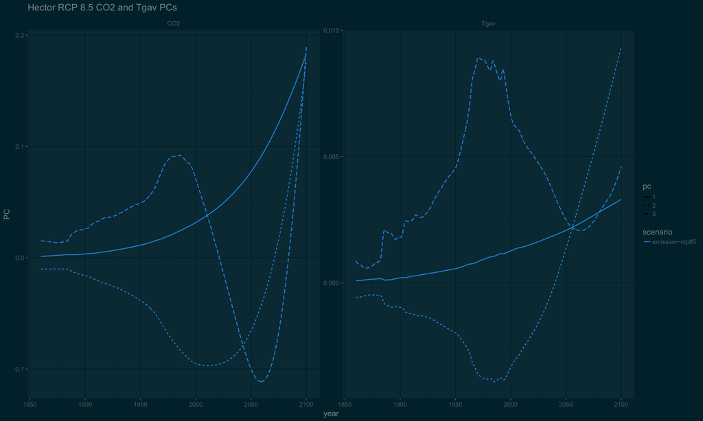

```r
plot_pcs(pca = pca_temp_co2_rcp85, pc_indx = 1:3) +
    facet_wrap('variable', scales = 'free') +
    labs(title = 'Hector RCP 8.5 CO2 and Tgav PCs')
```

**Conclusion:** I think that the story line still applies here. The first PC tells us something about warming at the begning vs the end. It makes sense to me that the wieght of the PC is greater for the CO2 vs the Tgav since there is an expontial increase in CO2 where are more of a linear incrase in Tgav. But the 2 other PCs kind of changed in shape.

# Summary

1. Increasing the ensmble size does not really change the PCs or the variance explained by the PCs.
2. Incorperating more of the years flattens out the PC – why?
3. I think that the first PC story line is consistent across the different scenarios and variable but I am not sure about the other PCs

## Questions

- Why do we want to have multiple scenarios contributing to a Hector vector PCA? When we are doing the MCMC won’t the likelihood function be comparing the PC from a single scenario at at time? I mean we aren’t ever doing to be calibrating to muliple rcps at a time will we?
- What do we want to do about the scaling? Do we want to remove the variance before the PCA? Because there is no way for prcomp to know the difference in the groups… the same about of variance is going to be removed from everything.
- Why do we muliply by the sign?